# IODS course project

# 3. Logistic regression

*We have preprocessed a data set on student alcohol consumption from the UCI Machine Learning Repository for further analysis. The exercise focuses on exploring the data and performing and interpreting logistic regression analysis. The following includes the codes and my explanations and interpretations for the analysis part.*

## 2) Reading the data into R

I read the joined student alcohol consumption data into R from my local folder:

```r
alc <- read.csv("data/alc.csv", header = TRUE, sep = ",")

colnames(alc)
```

```
##  [1] "X"          "school"     "sex"        "age"        "address"
##  [6] "famsize"    "Pstatus"    "Medu"       "Fedu"       "Mjob"
## [11] "Fjob"       "reason"     "nursery"    "internet"   "guardian"
## [16] "traveltime" "studytime"  "failures"   "schoolsup"  "famsup"
## [21] "paid"       "activities" "higher"     "romantic"   "famrel"
## [26] "freetime"   "goout"      "Dalc"       "Walc"       "health"
## [31] "absences"   "G1"         "G2"         "G3"         "alc_use"
## [36] "high_use"
```

Alc includes the data on student alcohol consumption from the UCI Machine Learning Repository. It includes the alcohol usage and the social, gender and study time attributes for 382 students in 36 variables.

## 3) Hypotheses

Let’s have a glimpse at the data:

```r
library(dplyr)
glimpse(alc)
```

```
## Observations: 382
## Variables: 36
## $ X          <int> 1, 2, 3, 4, 5, 6, 7, 8, 9, 10, 11, 12, 13, 14, 15, ...
## $ school     <fctr> GP, GP, GP, GP, GP, GP, GP, GP, GP, GP, GP, GP, GP...
## $ sex        <fctr> F, F, F, F, F, M, M, F, M, M, F, F, M, M, M, F, F,...
## $ age        <int> 18, 17, 15, 15, 16, 16, 16, 17, 15, 15, 15, 15, 15,...
## $ address    <fctr> U, U, U, U, U, U, U, U, U, U, U, U, U, U, U, U, U,...
## $ famsize    <fctr> GT3, GT3, LE3, GT3, GT3, LE3, LE3, GT3, LE3, GT3, ...
## $ Pstatus    <fctr> A, T, T, T, T, T, T, A, A, T, T, T, T, T, A, T, T,...
## $ Medu       <int> 4, 1, 1, 4, 3, 4, 2, 4, 3, 3, 4, 2, 4, 4, 2, 4, 4, ...
## $ Fedu       <int> 4, 1, 1, 2, 3, 3, 2, 4, 2, 4, 4, 1, 4, 3, 2, 4, 4, ...
## $ Mjob       <fctr> at_home, at_home, at_home, health, other, services...
## $ Fjob       <fctr> teacher, other, other, services, other, other, oth...
## $ reason     <fctr> course, course, other, home, home, reputation, hom...
## $ nursery    <fctr> yes, no, yes, yes, yes, yes, yes, yes, yes, yes, y...
```

[output cut: 23 more lines]

I am interested in the relationship between high/low alcohol use and age, gender, the frequency of going out with friends and the health condition of the students.

- My assumption is that high alcohol consumption becomes more likely at higher age (the ages of the subjects are between 15 and 22 years of age), because older students have more to spend and have more possibilities to buy alcohol.
- I think that boys are more likely to have high alcohol consumption compared to girls, since they want to show off.
- I expect that students who go out with friends more often have higher alcohol consumption.
- I think that the health condition is worse for students that have high alcohol consumption. Not just because alcohol is bad for one’s health, but also because people who drink less tend to be more concious about their health in general.

## 4) Distribution of the chosen variables and relationship with alcohol consumption

We explored the distribution of the chosen variables and their relationship with alcohol consumption.

### Age

```r
# access the tidyverse libraries dplyr and ggplot2
library(dplyr); library(ggplot2)

# Produce a cross-tabulation for age and high use of alcohol
mytable <- table(age = alc$age,high_use = alc$high_use)
mytable
```

```
##     high_use
## age  FALSE TRUE
##   15    63   18
##   16    79   28
##   17    64   36
##   18    54   27
##   19     7    4
##   20     1    0
##   22     0    1
```

```r
# A cross-tabulation with fractions for age and high use of alcohol
prop.table(mytable, 1)
```

```
##     high_use
## age      FALSE      TRUE
##   15 0.7777778 0.2222222
##   16 0.7383178 0.2616822
##   17 0.6400000 0.3600000
##   18 0.6666667 0.3333333
##   19 0.6363636 0.3636364
##   20 1.0000000 0.0000000
##   22 0.0000000 1.0000000
```

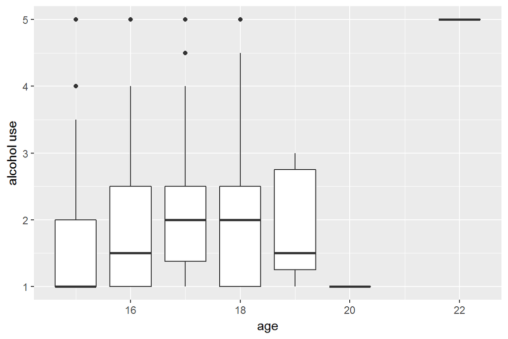

```r
# initialize a plot of high_use and age
g1 <- ggplot(alc, aes(x = age, y = alc_use, group = age))

# define the plot as a boxplot and draw it
g1 + geom_boxplot() + ylab("alcohol use")
```

Alcohol consumption seems to increase with age if we disregard the higher age group (19-22), because of the lack of data. Also the fraction of student’s that have a high use of alcohol (TRUE) shows an increasing trend increases between 15-18 years of age, although not as cleary.

### Gender

```r
# Produce a cross-tabulation for sex and high use of alcohol
mytable <- table(gender = alc$sex, high_use = alc$high_use)
mytable
```

```
##       high_use
## gender FALSE TRUE
##      F   156   42
##      M   112   72
```

```r
# A cross-tabulation with fractions for sex and high use of alcohol
prop.table(mytable, 1) %>% addmargins()
```

```
##       high_use
## gender     FALSE      TRUE       Sum
##    F   0.7878788 0.2121212 1.0000000
##    M   0.6086957 0.3913043 1.0000000
##    Sum 1.3965744 0.6034256 2.0000000
```

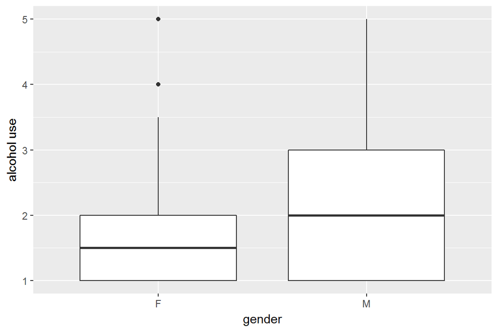

```r
# initialize a plot of high_use and G1
g1 <- ggplot(alc, aes(x = sex, y = alc_use))

# define the plot as a boxplot and draw it
g1 + geom_boxplot() + ylab("alcohol use") + xlab("gender")
```

The fraction of students with high intake of alcohol is almost twice as high among boys (39%) compared to girls (21%), confirming my hypothesis. The median alcohol consumption per week is also higher. The variation is higher in boys compared to girls.

### Going out

```r
# Produce a cross-tabulation for going-out frequency and high use of alcohol
mytable <- table(Going_out_frequency = alc$goout, high_use = alc$high_use)
mytable
```

```
##                    high_use
## Going_out_frequency FALSE TRUE
##                   1    19    3
##                   2    84   16
##                   3   103   23
##                   4    41   40
##                   5    21   32
```

```r
# A cross-tabulation with fractions for going-out frequency and high use of alcohol
prop.table(mytable, 1)
```

```
##                    high_use
## Going_out_frequency     FALSE      TRUE
##                   1 0.8636364 0.1363636
##                   2 0.8400000 0.1600000
##                   3 0.8174603 0.1825397
##                   4 0.5061728 0.4938272
##                   5 0.3962264 0.6037736
```

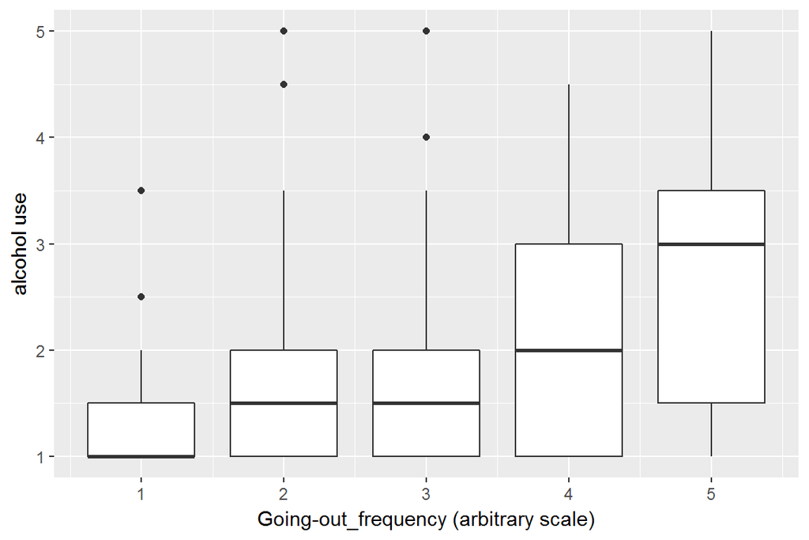

```r
# initialize a plot of high_use and goout
g1 <- ggplot(alc, aes(x = goout, y = alc_use, group = goout))

# define the plot as a boxplot and draw it
g1 + geom_boxplot() + ylab("alcohol use") + xlab("Going-out_frequency (arbitrary scale)")
```

Of course, alcohol consumption is higher in students that go out more often. Both the weekly consumption and the percentage of students with high alcohol intake are substantially higher when they go out more frequently.

### Health

```r
# Produce a cross-tabulation for health and high use of alcohol

mytable <- table(Health_status = alc$health, high_use = alc$high_use)
mytable
```

```
##              high_use
## Health_status FALSE TRUE
##             1    35   11
##             2    28   16
##             3    62   19
##             4    49   18
##             5    94   50
```

```r
# A cross-tabulation with percentages for health and high use of alcohol
prop.table(mytable, 1)
```

```
##              high_use
## Health_status     FALSE      TRUE
##             1 0.7608696 0.2391304
##             2 0.6363636 0.3636364
##             3 0.7654321 0.2345679
##             4 0.7313433 0.2686567
##             5 0.6527778 0.3472222
```

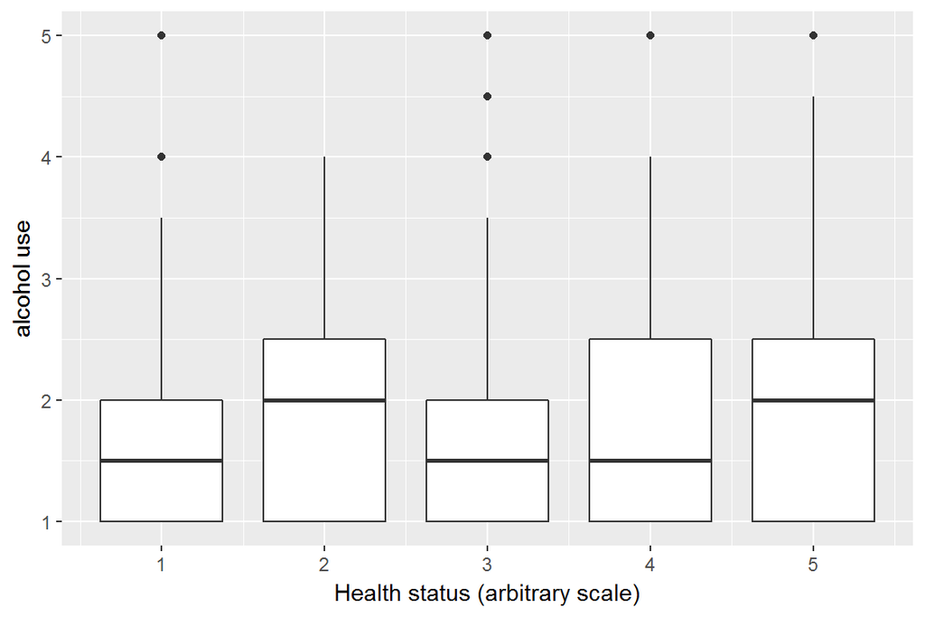

```r
# initialize a plot of high_use and goout
g1 <- ggplot(alc, aes(x = health, y = alc_use, group = health))

# define the plot as a boxplot and draw it
g1 + geom_boxplot() + ylab("alcohol use") + xlab("Health status (arbitrary scale)")
```

From this data set, we can not find a relationship between alcohol consumption and the students’ health status. At this young age, there is not yet an effect of high alcohol intake on how the students grade their health status.

## 5) Logical regression

We explore the relationship between the chosen variables and the binary high/low alcohol consumption variable as the target variable:

```r
# find the model with glm()
m <- glm(high_use ~ age + sex + goout + health, data = alc, family = "binomial")

# print out a summary of the model
summary(m)
```

```
##
## Call:
## glm(formula = high_use ~ age + sex + goout + health, family = "binomial",
##     data = alc)
##
## Deviance Residuals:
##     Min       1Q   Median       3Q      Max
## -1.6845  -0.8260  -0.5805   0.8702   2.5752
##
## Coefficients:
##             Estimate Std. Error z value Pr(>|z|)
## (Intercept)  -6.3505     1.8379  -3.455 0.000550 ***
## age           0.1365     0.1060   1.288 0.197871
## sexM          0.8442     0.2500   3.376 0.000734 ***
## goout         0.7454     0.1194   6.242 4.31e-10 ***
## health        0.0927     0.0904   1.025 0.305135
## ---
## Signif. codes:  0 '***' 0.001 '**' 0.01 '*' 0.05 '.' 0.1 ' ' 1
##
## (Dispersion parameter for binomial family taken to be 1)
##
##     Null deviance: 465.68  on 381  degrees of freedom
## Residual deviance: 400.16  on 377  degrees of freedom
## AIC: 410.16
##
## Number of Fisher Scoring iterations: 4
```

Two of the chosen predictor variables,gender and going-out frequency, are found to be significant predictors of high/low alcohol consumption. Men and frequent ‘clubbers’ are more likely to consume a lot of alcohol.

The following table shows the odds ratios for our predictor variables with 95%-confidence interval:

```r
# compute odds ratios (OR)
OR <- coef(m) %>% exp

# compute confidence intervals (CI)
CI <- confint(m) %>% exp
# print out the odds ratios with their confidence intervals
cbind(OR, CI)
```

```
##                      OR        2.5 %    97.5 %
## (Intercept) 0.001745951 4.399616e-05 0.0603997
## age         1.146297148 9.320413e-01 1.4139796
## sexM        2.326197406 1.431271e+00 3.8219054
## goout       2.107206412 1.677391e+00 2.6814626
## health      1.097133682 9.203935e-01 1.3129857
```

The odds ratio for gender (sexM) tells that boys have a 2.3 (95%-CI 1.4-3.8) times higher chance to be big users of alcohol compared to girls. The odds ratio for going out tells us that a unit increase of this variable (on a scale from 1-5) will increase the chance of being a heavy drinker by 2.1 (95%-CI 1.7-2.7). The confidence intervals of the odds ratios for age and health include 1, meaning that we cannot say for certain if an increase in these variables increase or descrease the probability of being a heavy drinker.

## 6) Performance of the model

```r
# define the model with the variables that had a statistical relationship with high/low alcohol consumption
m2 <- glm(high_use ~ sex + goout, data = alc, family = "binomial")

# predict() the probability of high_use
probabilities <- predict(m, type = "response")

# add the predicted probabilities to 'alc'
alc <- mutate(alc, probability = probabilities)

# use the probabilities to make a prediction of high_use
alc <- mutate(alc, prediction = probability > 0.5)
```

To evaluate the predicitve power of our model, we tabulated the predictions versus the actual values of high_use:

```r
# tabulate the target variable versus the predictions
my.table <- table(high_use = alc$high_use, prediction = alc$prediction)
my.table
```

```
##         prediction
## high_use FALSE TRUE
##    FALSE   248   20
##    TRUE     63   51
```

```r
# tabulate the  fractions of target variable versus the predictions
prop.table(my.table,1) %>% addmargins()
```

```
##         prediction
## high_use      FALSE       TRUE        Sum
##    FALSE 0.92537313 0.07462687 1.00000000
##    TRUE  0.55263158 0.44736842 1.00000000
##    Sum   1.47800471 0.52199529 2.00000000
```

This is a graphic visualization of the predictions and their actual values:

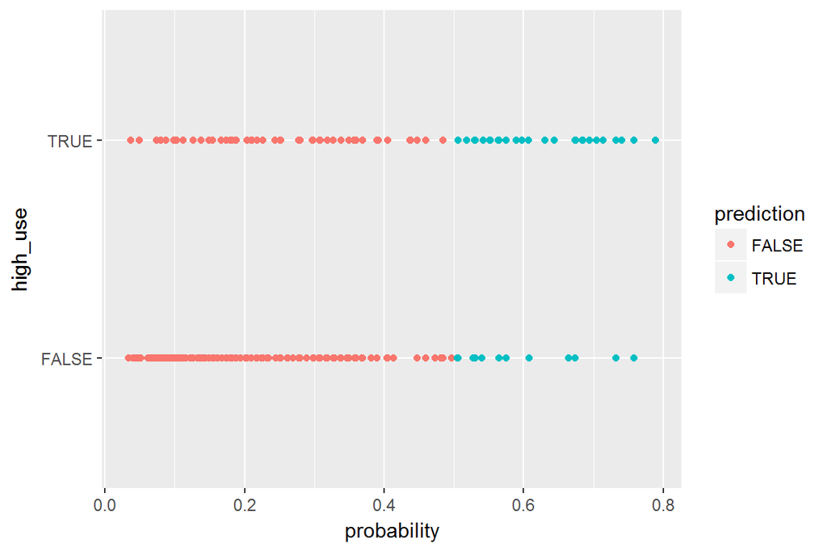

```r
# initialize a plot of 'high_use' versus 'probability' in 'alc'
g <- ggplot(alc, aes(x = probability, y = high_use, col = prediction))

# define the geom as points and draw the plot
g + geom_point()
```

We computed the training error by calculating the total proportion of inaccurately classified individuals.

```r
# define a loss function (mean prediction error)
loss_func <- function(class, prob) {
  n_wrong <- abs(class - prob) > 0.5
  mean(n_wrong)
}

# call loss_func to compute the average number of wrong predictions in the (training) data
loss_func(class = alc$high_use, prob = alc$probability)
```

```
## [1] 0.2172775
```

The model is good at identifying the individuals having low alcohol consumption, classifying these individuals correctly in 92.5% of the cases. The model performs poorly when it comes to the heavy drinkers, predicting them to have low alcohol consumption 55% of the time. knowing that most students are not heavy drinkers (I am very naive), I would’ve guessed that predicted that none of the students is a heavy drinker. In that case I would have guessed wrong in (114 heavy drinkers / 382 individuals in total =) 29.8% of the time. Mainly by picking out 45% of the heavy drinkers, the model performs slightly better than my naive guessing strategy: the model’s overal training error was 21.7%.

## 7 Bonus) 10-fold cross-validation

To test the model in a test-set (not used for training the model), We performed a 10-fold cross-validation. The performance error for the test set is given as output:

```r
# K-fold cross-validation
library(boot)
cv <- cv.glm(data = alc, cost = loss_func, glmfit = m, K = 10)

# average number of wrong predictions in the cross validation
cv$delta[1]
```

```
## [1] 0.2251309
```

In the test set, the model makes a wrong prediction in around 23% of the cases. Our model performs better compared to the model introduced in DataCamp, which had about 0.26 error.

## 8 Super-Bonus) Comparing the performance of different logistic regression models

We compared the performance of different logistic regression models. We defined models using 1 to as many as 27 prediction variables and evaluated the average number of wrong predictions in the training-set as well as the test error from a 10-fold cross-validaiton.

```r
cv.error <- 0
train.error <- 0

# define models using 1 to 27 prediction variables
for(numbofpred in 1:27) {

predvars <- paste(colnames(alc)[1:numbofpred], collapse = " + ")
m.formula <- paste("high_use ~ ", predvars) %>% as.formula()
m3 <- glm(m.formula, data = alc, family = "binomial")

# predict() the probability of high_use
probabilities <- predict(m3, type = "response")

# add the predicted probabilities to 'alc'
alc <- mutate(alc, probability3 = probabilities)

# use the probabilities to make a prediction of high_use
alc <- mutate(alc, prediction3 = probability3 > 0.5)

# compute the average number of wrong predictions in the (training) data
train.error[numbofpred] <- loss_func(class = alc$high_use, prob = alc$probability3)

# K-fold cross-validation
cv <- cv.glm(data = alc, cost = loss_func, glmfit = m3, K = 10)

# average number of wrong predictions in the cross validation
cv.error[numbofpred] <- cv$delta[1]

}
```

The test and training errors were plotted against the number of prediction variables used in the model.

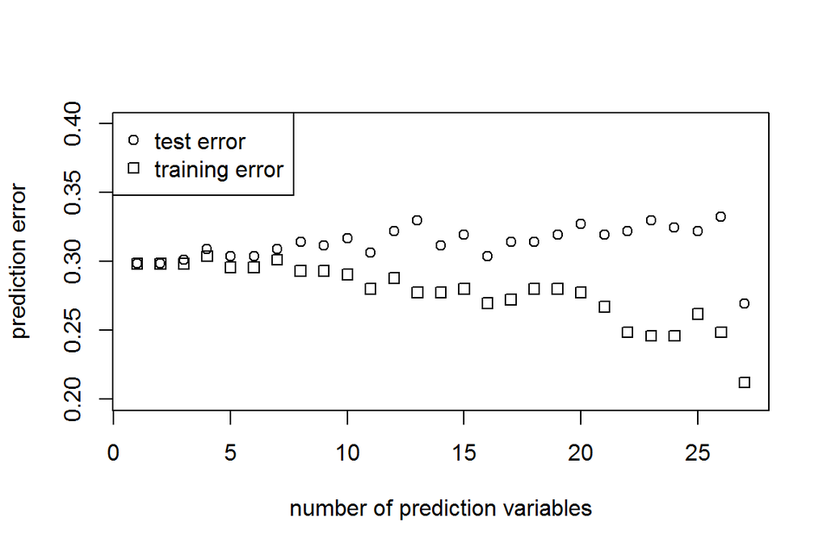

```r
plot(cv.error, xlab = "number of prediction variables", ylab="prediction error", ylim=c(0.2, 0.4))
points(train.error, pch = 0)
legend("topleft", legend = c("test error", "training error"), pch = c(1,0))
```

# 4. Clustering and classification

## 2. The Boston dataset

```r
# access the MASS package
library(MASS)
# load the data
data("Boston")

# explore the dataset
str(Boston)
```

```
## 'data.frame':    506 obs. of  14 variables:
##  $ crim   : num  0.00632 0.02731 0.02729 0.03237 0.06905 ...
##  $ zn     : num  18 0 0 0 0 0 12.5 12.5 12.5 12.5 ...
##  $ indus  : num  2.31 7.07 7.07 2.18 2.18 2.18 7.87 7.87 7.87 7.87 ...
##  $ chas   : int  0 0 0 0 0 0 0 0 0 0 ...
##  $ nox    : num  0.538 0.469 0.469 0.458 0.458 0.458 0.524 0.524 0.524 0.524 ...
##  $ rm     : num  6.58 6.42 7.18 7 7.15 ...
##  $ age    : num  65.2 78.9 61.1 45.8 54.2 58.7 66.6 96.1 100 85.9 ...
##  $ dis    : num  4.09 4.97 4.97 6.06 6.06 ...
##  $ rad    : int  1 2 2 3 3 3 5 5 5 5 ...
##  $ tax    : num  296 242 242 222 222 222 311 311 311 311 ...
##  $ ptratio: num  15.3 17.8 17.8 18.7 18.7 18.7 15.2 15.2 15.2 15.2 ...
##  $ black  : num  397 397 393 395 397 ...
##  $ lstat  : num  4.98 9.14 4.03 2.94 5.33 ...
##  $ medv   : num  24 21.6 34.7 33.4 36.2 28.7 22.9 27.1 16.5 18.9 ...
```

```r
dim(Boston)
```

```
## [1] 506  14
```

The data set contains data for suburbs in the Boston metropolitan area. It includes variables that affect the value of homes, such as crime rate, pollution (NOX concentration) and accessibility to radial highways. The data set includes 506 observations described in 14 variables.

## 3. Exploring the Boston data set

```r
summary(Boston)
```

```
##       crim                zn             indus            chas
##  Min.   : 0.00632   Min.   :  0.00   Min.   : 0.46   Min.   :0.00000
##  1st Qu.: 0.08204   1st Qu.:  0.00   1st Qu.: 5.19   1st Qu.:0.00000
##  Median : 0.25651   Median :  0.00   Median : 9.69   Median :0.00000
##  Mean   : 3.61352   Mean   : 11.36   Mean   :11.14   Mean   :0.06917
##  3rd Qu.: 3.67708   3rd Qu.: 12.50   3rd Qu.:18.10   3rd Qu.:0.00000
##  Max.   :88.97620   Max.   :100.00   Max.   :27.74   Max.   :1.00000
##       nox               rm             age              dis
##  Min.   :0.3850   Min.   :3.561   Min.   :  2.90   Min.   : 1.130
##  1st Qu.:0.4490   1st Qu.:5.886   1st Qu.: 45.02   1st Qu.: 2.100
##  Median :0.5380   Median :6.208   Median : 77.50   Median : 3.207
##  Mean   :0.5547   Mean   :6.285   Mean   : 68.57   Mean   : 3.795
##  3rd Qu.:0.6240   3rd Qu.:6.623   3rd Qu.: 94.08   3rd Qu.: 5.188
##  Max.   :0.8710   Max.   :8.780   Max.   :100.00   Max.   :12.127
##       rad              tax           ptratio          black
##  Min.   : 1.000   Min.   :187.0   Min.   :12.60   Min.   :  0.32
##  1st Qu.: 4.000   1st Qu.:279.0   1st Qu.:17.40   1st Qu.:375.38
##  Median : 5.000   Median :330.0   Median :19.05   Median :391.44
##  Mean   : 9.549   Mean   :408.2   Mean   :18.46   Mean   :356.67
##  3rd Qu.:24.000   3rd Qu.:666.0   3rd Qu.:20.20   3rd Qu.:396.23
##  Max.   :24.000   Max.   :711.0   Max.   :22.00   Max.   :396.90
##      lstat            medv
##  Min.   : 1.73   Min.   : 5.00
##  1st Qu.: 6.95   1st Qu.:17.02
##  Median :11.36   Median :21.20
##  Mean   :12.65   Mean   :22.53
##  3rd Qu.:16.95   3rd Qu.:25.00
##  Max.   :37.97   Max.   :50.00
```

```r
pdf(file = "plots/Boston_pairplot.pdf")
pairs(Boston, lower.panel = NULL, gap=0.5, pch = 16, cex =0.1)
dev.off()
```

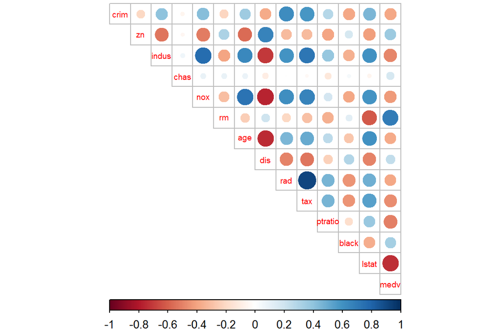

```r
library(corrplot)

cor_matrix<-cor(Boston)
corrplot(cor_matrix, method="circle", type = "upper", cl.pos = "b", tl.pos = "d", tl.cex = 0.6)
```

The proportion of non-retail business acres per town (indus) has strong positive correlaiton with air pollution (nox), the full-value property-tax rate (tax) and the percentage of the population with lower status (lstat), which is to be expected in towns with industry. Non-retail businesses (indus) are often in close proximity to employment centres (dis). The proportion of owner-occupied units built prior to 1940 (age) is often bigger in areas with industry.

Crime rate (crim) tends to be higher in towns with good accessibility to radial highways (rad) and a high property-tax rate (tax).

The median value of the owner-occupied homes (medv) has a strong positive correlation with the average number of rooms per dwelling (rm) and a strong negative correlation with the percentage of the population with lower status. The lower class lives in smaller homes with lower value.

The Boston metropolitan area is a mainly white area. The variable black is high when the proportion of blacks is low. The median value is 391.4, which corresponds to 0.4% blacks.

## 4. Some more data wrangling

The data was standardized and summaries of the standardized data were printed:

```r
# center and standardize variables
boston_scaled <- scale(Boston)

# summaries of the scaled variables
summary(boston_scaled)
```

```
##       crim                 zn               indus
##  Min.   :-0.419367   Min.   :-0.48724   Min.   :-1.5563
##  1st Qu.:-0.410563   1st Qu.:-0.48724   1st Qu.:-0.8668
##  Median :-0.390280   Median :-0.48724   Median :-0.2109
##  Mean   : 0.000000   Mean   : 0.00000   Mean   : 0.0000
##  3rd Qu.: 0.007389   3rd Qu.: 0.04872   3rd Qu.: 1.0150
##  Max.   : 9.924110   Max.   : 3.80047   Max.   : 2.4202
##       chas              nox                rm               age
##  Min.   :-0.2723   Min.   :-1.4644   Min.   :-3.8764   Min.   :-2.3331
##  1st Qu.:-0.2723   1st Qu.:-0.9121   1st Qu.:-0.5681   1st Qu.:-0.8366
##  Median :-0.2723   Median :-0.1441   Median :-0.1084   Median : 0.3171
##  Mean   : 0.0000   Mean   : 0.0000   Mean   : 0.0000   Mean   : 0.0000
##  3rd Qu.:-0.2723   3rd Qu.: 0.5981   3rd Qu.: 0.4823   3rd Qu.: 0.9059
##  Max.   : 3.6648   Max.   : 2.7296   Max.   : 3.5515   Max.   : 1.1164
##       dis               rad               tax             ptratio
##  Min.   :-1.2658   Min.   :-0.9819   Min.   :-1.3127   Min.   :-2.7047
##  1st Qu.:-0.8049   1st Qu.:-0.6373   1st Qu.:-0.7668   1st Qu.:-0.4876
##  Median :-0.2790   Median :-0.5225   Median :-0.4642   Median : 0.2746
##  Mean   : 0.0000   Mean   : 0.0000   Mean   : 0.0000   Mean   : 0.0000
##  3rd Qu.: 0.6617   3rd Qu.: 1.6596   3rd Qu.: 1.5294   3rd Qu.: 0.8058
##  Max.   : 3.9566   Max.   : 1.6596   Max.   : 1.7964   Max.   : 1.6372
##      black             lstat              medv
##  Min.   :-3.9033   Min.   :-1.5296   Min.   :-1.9063
##  1st Qu.: 0.2049   1st Qu.:-0.7986   1st Qu.:-0.5989
##  Median : 0.3808   Median :-0.1811   Median :-0.1449
##  Mean   : 0.0000   Mean   : 0.0000   Mean   : 0.0000
##  3rd Qu.: 0.4332   3rd Qu.: 0.6024   3rd Qu.: 0.2683
##  Max.   : 0.4406   Max.   : 3.5453   Max.   : 2.9865
```

```r
var(boston_scaled)
```

```
##                crim          zn       indus         chas         nox
## crim     1.00000000 -0.20046922  0.40658341 -0.055891582  0.42097171
## zn      -0.20046922  1.00000000 -0.53382819 -0.042696719 -0.51660371
## indus    0.40658341 -0.53382819  1.00000000  0.062938027  0.76365145
## chas    -0.05589158 -0.04269672  0.06293803  1.000000000  0.09120281
## nox      0.42097171 -0.51660371  0.76365145  0.091202807  1.00000000
## rm      -0.21924670  0.31199059 -0.39167585  0.091251225 -0.30218819
## age      0.35273425 -0.56953734  0.64477851  0.086517774  0.73147010
## dis     -0.37967009  0.66440822 -0.70802699 -0.099175780 -0.76923011
## rad      0.62550515 -0.31194783  0.59512927 -0.007368241  0.61144056
## tax      0.58276431 -0.31456332  0.72076018 -0.035586518  0.66802320
## ptratio  0.28994558 -0.39167855  0.38324756 -0.121515174  0.18893268
## black   -0.38506394  0.17552032 -0.35697654  0.048788485 -0.38005064
## lstat    0.45562148 -0.41299457  0.60379972 -0.053929298  0.59087892
## medv    -0.38830461  0.36044534 -0.48372516  0.175260177 -0.42732077
##                  rm         age         dis          rad         tax
## crim    -0.21924670  0.35273425 -0.37967009  0.625505145  0.58276431
## zn       0.31199059 -0.56953734  0.66440822 -0.311947826 -0.31456332
## indus   -0.39167585  0.64477851 -0.70802699  0.595129275  0.72076018
## chas     0.09125123  0.08651777 -0.09917578 -0.007368241 -0.03558652
## nox     -0.30218819  0.73147010 -0.76923011  0.611440563  0.66802320
## rm       1.00000000 -0.24026493  0.20524621 -0.209846668 -0.29204783
## age     -0.24026493  1.00000000 -0.74788054  0.456022452  0.50645559
## dis      0.20524621 -0.74788054  1.00000000 -0.494587930 -0.53443158
## rad     -0.20984667  0.45602245 -0.49458793  1.000000000  0.91022819
## tax     -0.29204783  0.50645559 -0.53443158  0.910228189  1.00000000
## ptratio -0.35550149  0.26151501 -0.23247054  0.464741179  0.46085304
## black    0.12806864 -0.27353398  0.29151167 -0.444412816 -0.44180801
## lstat   -0.61380827  0.60233853 -0.49699583  0.488676335  0.54399341
## medv     0.69535995 -0.37695457  0.24992873 -0.381626231 -0.46853593
##            ptratio       black      lstat       medv
## crim     0.2899456 -0.38506394  0.4556215 -0.3883046
## zn      -0.3916785  0.17552032 -0.4129946  0.3604453
## indus    0.3832476 -0.35697654  0.6037997 -0.4837252
## chas    -0.1215152  0.04878848 -0.0539293  0.1752602
## nox      0.1889327 -0.38005064  0.5908789 -0.4273208
## rm      -0.3555015  0.12806864 -0.6138083  0.6953599
## age      0.2615150 -0.27353398  0.6023385 -0.3769546
## dis     -0.2324705  0.29151167 -0.4969958  0.2499287
## rad      0.4647412 -0.44441282  0.4886763 -0.3816262
## tax      0.4608530 -0.44180801  0.5439934 -0.4685359
## ptratio  1.0000000 -0.17738330  0.3740443 -0.5077867
## black   -0.1773833  1.00000000 -0.3660869  0.3334608
## lstat    0.3740443 -0.36608690  1.0000000 -0.7376627
## medv    -0.5077867  0.33346082 -0.7376627  1.0000000
```

The mean of the variables was set to 0 and variance to 1.

The crim variable was taken out and converted into a categorical variable, using the quantiles as bins.

```r
# change the object to data frame
boston_scaled <- as.data.frame(boston_scaled)

# save the scaled crim as scaled_crim
scaled_crim <- boston_scaled$crim

# create a quantile vector of crim and print it
bins <- quantile(scaled_crim)

# create a categorical variable 'crime'
crime <- cut(scaled_crim, breaks = bins, include.lowest = TRUE, label = c("low", "med_low", "med_high", "high"))

# look at the table of the new factor crime
table(crime)
```

```
## crime
##      low  med_low med_high     high
##      127      126      126      127
```

```r
# remove original crim from the dataset
boston_scaled <- dplyr::select(boston_scaled, -crim)

# add the new categorical value to scaled data
boston_scaled <- data.frame(boston_scaled, crime)
```

The dataset was divided into a train set with 80% of the observations and a test set with the remaining 20%:

```r
# number of rows in the Boston dataset
n <- nrow(boston_scaled)

# choose randomly 80% of the rows
ind <- sample(n,  size = n * 0.8)

# create train set
train <- boston_scaled[ind,]

# create test set
test <- boston_scaled[-ind,]
```

## 5. Linear discriminant analysis

A linear discriminant analysis (LDA) was performed using the categorical crime variable as a target variable and all other variables as predictor variables. A LDA biplot was drawn:

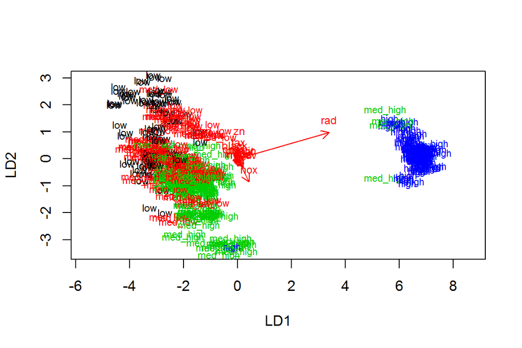

```r
# linear discriminant analysis
lda.fit <- lda(crime ~ . , data = train)

# the function for lda biplot arrows
lda.arrows <- function(x, myscale = 1, arrow_heads = 0.1, color = "red", tex = 0.75, choices = c(1,2)){
  heads <- coef(x)
  arrows(x0 = 0, y0 = 0,
         x1 = myscale * heads[,choices[1]],
         y1 = myscale * heads[,choices[2]], col=color, length = arrow_heads)
  text(myscale * heads[,choices], labels = row.names(heads),
       cex = tex, col=color, pos=3)
}

# target classes as numeric
classes <- as.numeric(train$crime)

# plot the lda results
plot(lda.fit, dimen = 2, col = classes, pch = classes)
lda.arrows(lda.fit, myscale = 1)
```

The most influencial linear separator for crime rate is accessibility to radial highways (rad).

## 6. Prediction of classes with the LDA model on the test data

Using our LDA model, we predicted the crime classes based on the test data. Results were cross tabulated:

```r
# save the correct classes from test data
correct_classes <- test$crime

# remove the crime variable from test data
test <- dplyr::select(test, -crime)

# predict classes with test data
lda.pred <- predict(lda.fit, newdata = test)

# cross tabulate the results
table(correct = correct_classes, predicted = lda.pred$class)
```

```
##           predicted
## correct    low med_low med_high high
##   low       19       6        5    0
##   med_low    2      17        7    0
##   med_high   0       3       19    2
##   high       0       0        0   22
```

The model is good at predicting the high classes from the test data, but has more difficulty with the lower classes.